# Starbucks Capstone Challenge

### Introduction

This data set contains simulated data that mimics customer behavior on the Starbucks rewards mobile app. Once every few days, Starbucks sends out an offer to users of the mobile app. An offer can be merely an advertisement for a drink or an actual offer such as a discount or BOGO (buy one get one free). Some users might not receive any offer during certain weeks.

Not all users receive the same offer, and that is the challenge to solve with this data set.

Your task is to combine transaction, demographic and offer data to determine which demographic groups respond best to which offer type. This data set is a simplified version of the real Starbucks app because the underlying simulator only has one product whereas Starbucks actually sells dozens of products.

Every offer has a validity period before the offer expires. As an example, a BOGO offer might be valid for only 5 days. You'll see in the data set that informational offers have a validity period even though these ads are merely providing information about a product; for example, if an informational offer has 7 days of validity, you can assume the customer is feeling the influence of the offer for 7 days after receiving the advertisement.

You'll be given transactional data showing user purchases made on the app including the timestamp of purchase and the amount of money spent on a purchase. This transactional data also has a record for each offer that a user receives as well as a record for when a user actually views the offer. There are also records for when a user completes an offer.

Keep in mind as well that someone using the app might make a purchase through the app without having received an offer or seen an offer.

### Example

To give an example, a user could receive a discount offer buy 10 dollars get 2 off on Monday. The offer is valid for 10 days from receipt. If the customer accumulates at least 10 dollars in purchases during the validity period, the customer completes the offer.

However, there are a few things to watch out for in this data set. Customers do not opt into the offers that they receive; in other words, a user can receive an offer, never actually view the offer, and still complete the offer. For example, a user might receive the "buy 10 dollars get 2 dollars off offer", but the user never opens the offer during the 10 day validity period. The customer spends 15 dollars during those ten days. There will be an offer completion record in the data set; however, the customer was not influenced by the offer because the customer never viewed the offer.

### Cleaning

This makes data cleaning especially important and tricky.

You'll also want to take into account that some demographic groups will make purchases even if they don't receive an offer. From a business perspective, if a customer is going to make a 10 dollar purchase without an offer anyway, you wouldn't want to send a buy 10 dollars get 2 dollars off offer. You'll want to try to assess what a certain demographic group will buy when not receiving any offers.

### Final Advice

Because this is a capstone project, you are free to analyze the data any way you see fit. For example, you could build a machine learning model that predicts how much someone will spend based on demographics and offer type. Or you could build a model that predicts whether or not someone will respond to an offer. Or, you don't need to build a machine learning model at all. You could develop a set of heuristics that determine what offer you should send to each customer (i.e., 75 percent of women customers who were 35 years old responded to offer A vs 40 percent from the same demographic to offer B, so send offer A).

# Data Sets

The data is contained in three files:

- portfolio.json - containing offer ids and meta data about each offer (duration, type, etc.)
- profile.json - demographic data for each customer
- transcript.json - records for transactions, offers received, offers viewed, and offers completed

Here is the schema and explanation of each variable in the files:

**portfolio.json**

- id (string) - offer id
- offer_type (string) - type of offer ie BOGO, discount, informational
- difficulty (int) - minimum required spend to complete an offer
- reward (int) - reward given for completing an offer
- duration (int) - time for offer to be open, in days
- channels (list of strings)

**profile.json**

- age (int) - age of the customer
- became_member_on (int) - date when customer created an app account
- gender (str) - gender of the customer (note some entries contain 'O' for other rather than M or F)
- id (str) - customer id
- income (float) - customer's income

**transcript.json**

- event (str) - record description (ie transaction, offer received, offer viewed, etc.)
- person (str) - customer id
- time (int) - time in hours since start of test. The data begins at time t=0
- value - (dict of strings) - either an offer id or transaction amount depending on the record

**Note:** If you are using the workspace, you will need to go to the terminal and run the command `conda update pandas` before reading in the files. This is because the version of pandas in the workspace cannot read in the transcript.json file correctly, but the newest version of pandas can. You can access the termnal from the orange icon in the top left of this notebook.

You can see how to access the terminal and how the install works using the two images below. First you need to access the terminal:

[figure not shown]

Then you will want to run the above command:

[figure not shown]

Finally, when you enter back into the notebook (use the jupyter icon again), you should be able to run the below cell without any errors.

```python
# in case is needed intall the widgets package
# !pip install ipywidgets
```

```python
import pandas as pd
import numpy as np
import math
import json

import matplotlib.pyplot as plt
import seaborn as sns

import ipywidgets as widgets
from IPython.display import display

from sklearn.preprocessing import MultiLabelBinarizer
from sklearn.preprocessing import MinMaxScaler
from sklearn.model_selection import train_test_split, GridSearchCV
from sklearn.svm import SVC
from sklearn.tree import DecisionTreeClassifier
from sklearn.naive_bayes import GaussianNB
from sklearn.neighbors import KNeighborsClassifier
from sklearn.linear_model import LogisticRegression
from sklearn.ensemble import RandomForestRegressor

from sklearn.metrics import f1_score
from sklearn.metrics import precision_score
from sklearn.metrics import recall_score
from sklearn.metrics import accuracy_score

% matplotlib inline
```

```python
# read in the json files
portfolio = pd.read_json('data/portfolio.json', orient='records', lines=True)
profile = pd.read_json('data/profile.json', orient='records', lines=True)
transcript = pd.read_json('data/transcript.json', orient='records', lines=True)
```

# 1. Data Cleaning

## 1.1 Portfolio DataFrame

The required operations to clean the portfolio DF are:

```python
portfolio.head()
```

|  | channels | difficulty | duration | id | offer_type | reward |
| --- | --- | --- | --- | --- | --- | --- |
| 0 | [email, mobile, social] | 10 | 7 | ae264e3637204a6fb9bb56bc8210ddfd | bogo | 10 |
| 1 | [web, email, mobile, social] | 10 | 5 | 4d5c57ea9a6940dd891ad53e9dbe8da0 | bogo | 10 |
| 2 | [web, email, mobile] | 0 | 4 | 3f207df678b143eea3cee63160fa8bed | informational | 0 |
| 3 | [web, email, mobile] | 5 | 7 | 9b98b8c7a33c4b65b9aebfe6a799e6d9 | bogo | 5 |
| 4 | [web, email] | 20 | 10 | 0b1e1539f2cc45b7b9fa7c272da2e1d7 | discount | 5 |

```python
df_portfolio = portfolio.copy()
```

```python
# extract the contact channels as columns
mlb = MultiLabelBinarizer()

channels = pd.DataFrame(mlb.fit_transform(df_portfolio['channels']),
                       columns=mlb.classes_,
                       index=portfolio.index)
# concat channels & df_portfolio
df_portfolio = pd.concat([df_portfolio, channels], axis=1)
# drop unnecessary column
df_portfolio.drop(columns=['channels'], inplace=True)
```

```python
# rename columns
df_portfolio.rename(columns={'id':'offer_id', 'id':'offer_id'}, inplace=True)
# reindex DF
portfolio_index = ['offer_id', 'offer_type', 'difficulty', 'duration',
                   'reward', 'email', 'mobile', 'social', 'web']
df_portfolio = df_portfolio.reindex(portfolio_index, axis=1)
```

```python
df_portfolio
```

|  | offer_id | offer_type | difficulty | duration | reward | email | mobile | social | web |
| --- | --- | --- | --- | --- | --- | --- | --- | --- | --- |
| 0 | ae264e3637204a6fb9bb56bc8210ddfd | bogo | 10 | 7 | 10 | 1 | 1 | 1 | 0 |
| 1 | 4d5c57ea9a6940dd891ad53e9dbe8da0 | bogo | 10 | 5 | 10 | 1 | 1 | 1 | 1 |
| 2 | 3f207df678b143eea3cee63160fa8bed | informational | 0 | 4 | 0 | 1 | 1 | 0 | 1 |
| 3 | 9b98b8c7a33c4b65b9aebfe6a799e6d9 | bogo | 5 | 7 | 5 | 1 | 1 | 0 | 1 |
| 4 | 0b1e1539f2cc45b7b9fa7c272da2e1d7 | discount | 20 | 10 | 5 | 1 | 0 | 0 | 1 |
| 5 | 2298d6c36e964ae4a3e7e9706d1fb8c2 | discount | 7 | 7 | 3 | 1 | 1 | 1 | 1 |
| 6 | fafdcd668e3743c1bb461111dcafc2a4 | discount | 10 | 10 | 2 | 1 | 1 | 1 | 1 |
| 7 | 5a8bc65990b245e5a138643cd4eb9837 | informational | 0 | 3 | 0 | 1 | 1 | 1 | 0 |
| 8 | f19421c1d4aa40978ebb69ca19b0e20d | bogo | 5 | 5 | 5 | 1 | 1 | 1 | 1 |
| 9 | 2906b810c7d4411798c6938adc9daaa5 | discount | 10 | 7 | 2 | 1 | 1 | 0 | 1 |

## 1.2 Profile

The required operations to clean th profile dataframe:

- Drop age values == 118
- Drop NaN values for income and gender columns
- Dateformat became_member_on
- Binary values for gender column

```python
df_profile = profile.copy()
df_profile.head()
```

|  | age | became_member_on | gender | id | income |
| --- | --- | --- | --- | --- | --- |
| 0 | 118 | 20170212 | None | 68be06ca386d4c31939f3a4f0e3dd783 | NaN |
| 1 | 55 | 20170715 | F | 0610b486422d4921ae7d2bf64640c50b | 112000.0 |
| 2 | 118 | 20180712 | None | 38fe809add3b4fcf9315a9694bb96ff5 | NaN |
| 3 | 75 | 20170509 | F | 78afa995795e4d85b5d9ceeca43f5fef | 100000.0 |
| 4 | 118 | 20170804 | None | a03223e636434f42ac4c3df47e8bac43 | NaN |

```python
df_profile.info()
```

```
<class 'pandas.core.frame.DataFrame'>
RangeIndex: 17000 entries, 0 to 16999
Data columns (total 5 columns):
age                 17000 non-null int64
became_member_on    17000 non-null int64
gender              14825 non-null object
id                  17000 non-null object
income              14825 non-null float64
dtypes: float64(1), int64(2), object(2)
memory usage: 664.1+ KB
```

```python
# Show statistical information
df_profile.describe().T
```

|  | count | mean | std | min | 25% | 50% | 75% | max |
| --- | --- | --- | --- | --- | --- | --- | --- | --- |
| age | 17000.0 | 6.253141e+01 | 26.738580 | 18.0 | 45.0 | 58.0 | 73.0 | 118.0 |
| became_member_on | 17000.0 | 2.016703e+07 | 11677.499961 | 20130729.0 | 20160526.0 | 20170802.0 | 20171230.0 | 20180726.0 |
| income | 14825.0 | 6.540499e+04 | 21598.299410 | 30000.0 | 49000.0 | 64000.0 | 80000.0 | 120000.0 |

```python
# rename ID column
df_profile.rename(columns={'id':'customer_id'}, inplace=True)
```

```python
df_profile.loc[df_profile['age'] == 118, 'age'] = np.nan
df_profile['gender'].fillna(value=np.nan, inplace=True)
```

```python
# drop missing values
df_profile.dropna(subset=['age', 'gender', 'income'], inplace=True)
```

```python
# Datetime format
df_profile['became_member_on'] = pd.to_datetime(df_profile.became_member_on, format='%Y%m%d', errors='ignore')
```

```python
# extract Subscription year
df_profile['subscription_year'] = df_profile['became_member_on'].dt.year
```

```python
# income groups
df_profile['income_group'] = pd.cut(df_profile['income'], bins=[29999, 60000, 90000, 120000],
                                    labels=['Low income', 'Middle income', 'Upper income'])
```

```python
# age groups
df_profile['age_group'] = pd.cut(df_profile['age'], bins=[17,25,35,65,103],
                                 labels=['teenagers','young-adults','adults','seniors'])
```

```python
profile_index = ['customer_id', 'gender', 'age', 'age_group', 'became_member_on', 'subscription_year',
             'income', 'income_group']
df_profile = df_profile.reindex(profile_index, axis=1)
```

```python
df_profile.head()
```

|  | customer_id | gender | age | age_group | became_member_on | subscription_year | income | income_group |
| --- | --- | --- | --- | --- | --- | --- | --- | --- |
| 1 | 0610b486422d4921ae7d2bf64640c50b | F | 55.0 | adults | 2017-07-15 | 2017 | 112000.0 | Upper income |
| 3 | 78afa995795e4d85b5d9ceeca43f5fef | F | 75.0 | seniors | 2017-05-09 | 2017 | 100000.0 | Upper income |
| 5 | e2127556f4f64592b11af22de27a7932 | M | 68.0 | seniors | 2018-04-26 | 2018 | 70000.0 | Middle income |
| 8 | 389bc3fa690240e798340f5a15918d5c | M | 65.0 | adults | 2018-02-09 | 2018 | 53000.0 | Low income |
| 12 | 2eeac8d8feae4a8cad5a6af0499a211d | M | 58.0 | adults | 2017-11-11 | 2017 | 51000.0 | Low income |

## 1.3. transcript

The required operations to clean the transcript dataframe:

- unstack amount and offer id columns
- set time unit in days

```python
df_transcript = transcript.copy()
df_transcript.head()
```

|  | event | person | time | value |
| --- | --- | --- | --- | --- |
| 0 | offer received | 78afa995795e4d85b5d9ceeca43f5fef | 0 | {'offer id': '9b98b8c7a33c4b65b9aebfe6a799e6d9'} |
| 1 | offer received | a03223e636434f42ac4c3df47e8bac43 | 0 | {'offer id': '0b1e1539f2cc45b7b9fa7c272da2e1d7'} |
| 2 | offer received | e2127556f4f64592b11af22de27a7932 | 0 | {'offer id': '2906b810c7d4411798c6938adc9daaa5'} |
| 3 | offer received | 8ec6ce2a7e7949b1bf142def7d0e0586 | 0 | {'offer id': 'fafdcd668e3743c1bb461111dcafc2a4'} |
| 4 | offer received | 68617ca6246f4fbc85e91a2a49552598 | 0 | {'offer id': '4d5c57ea9a6940dd891ad53e9dbe8da0'} |

```python
# unpack value column
df_transcript = pd.concat([df_transcript, pd.DataFrame((d for idx, d in df_transcript['value'].iteritems()))], axis=1).fillna(0)
# integrate offer id & offer_id
df_transcript['offer_id'] = np.where(df_transcript['offer id'] == 0, df_transcript['offer_id'], df_transcript['offer id'])
# drop unnecesary columns
df_transcript.drop(columns=['offer id', 'value'], inplace=True)
```

```python
# set time in a daily bases
df_transcript['time'] = df_transcript['time']//24
```

```python
# rename columns
df_transcript.rename(columns={'person':'customer_id', 'event':'offer_status'}, inplace=True)
# reindex DF
transcript_index = ['customer_id', 'offer_id', 'offer_status', 'time', 'amount', 'reward']
df_transcript = df_transcript.reindex(transcript_index, axis=1)
```

```python
df_transcript.head()
```

|  | customer_id | offer_id | offer_status | time | amount | reward |
| --- | --- | --- | --- | --- | --- | --- |
| 0 | 78afa995795e4d85b5d9ceeca43f5fef | 9b98b8c7a33c4b65b9aebfe6a799e6d9 | offer received | 0 | 0.0 | 0.0 |
| 1 | a03223e636434f42ac4c3df47e8bac43 | 0b1e1539f2cc45b7b9fa7c272da2e1d7 | offer received | 0 | 0.0 | 0.0 |
| 2 | e2127556f4f64592b11af22de27a7932 | 2906b810c7d4411798c6938adc9daaa5 | offer received | 0 | 0.0 | 0.0 |
| 3 | 8ec6ce2a7e7949b1bf142def7d0e0586 | fafdcd668e3743c1bb461111dcafc2a4 | offer received | 0 | 0.0 | 0.0 |
| 4 | 68617ca6246f4fbc85e91a2a49552598 | 4d5c57ea9a6940dd891ad53e9dbe8da0 | offer received | 0 | 0.0 | 0.0 |

### 1.4 Master Table

```python
# merge tables to build a master DF
df_master = df_profile.merge(df_transcript, on='customer_id')
df_master = df_master.merge(df_portfolio, on='offer_id')
```

```python
df_master.head()
```

|  | customer_id | gender | age | age_group | became_member_on | subscription_year | income | income_group | offer_id | offer_status | ... | amount | reward_x | offer_type | difficulty | duration | reward_y | email | mobile | social | web |
| --- | --- | --- | --- | --- | --- | --- | --- | --- | --- | --- | --- | --- | --- | --- | --- | --- | --- | --- | --- | --- | --- |
| 0 | 0610b486422d4921ae7d2bf64640c50b | F | 55.0 | adults | 2017-07-15 | 2017 | 112000.0 | Upper income | 9b98b8c7a33c4b65b9aebfe6a799e6d9 | offer received | ... | 0.0 | 0.0 | bogo | 5 | 7 | 5 | 1 | 1 | 0 | 1 |
| 1 | 0610b486422d4921ae7d2bf64640c50b | F | 55.0 | adults | 2017-07-15 | 2017 | 112000.0 | Upper income | 9b98b8c7a33c4b65b9aebfe6a799e6d9 | offer completed | ... | 0.0 | 5.0 | bogo | 5 | 7 | 5 | 1 | 1 | 0 | 1 |
| 2 | 78afa995795e4d85b5d9ceeca43f5fef | F | 75.0 | seniors | 2017-05-09 | 2017 | 100000.0 | Upper income | 9b98b8c7a33c4b65b9aebfe6a799e6d9 | offer received | ... | 0.0 | 0.0 | bogo | 5 | 7 | 5 | 1 | 1 | 0 | 1 |
| 3 | 78afa995795e4d85b5d9ceeca43f5fef | F | 75.0 | seniors | 2017-05-09 | 2017 | 100000.0 | Upper income | 9b98b8c7a33c4b65b9aebfe6a799e6d9 | offer viewed | ... | 0.0 | 0.0 | bogo | 5 | 7 | 5 | 1 | 1 | 0 | 1 |
| 4 | 78afa995795e4d85b5d9ceeca43f5fef | F | 75.0 | seniors | 2017-05-09 | 2017 | 100000.0 | Upper income | 9b98b8c7a33c4b65b9aebfe6a799e6d9 | offer completed | ... | 0.0 | 5.0 | bogo | 5 | 7 | 5 | 1 | 1 | 0 | 1 |

5 rows × 21 columns

## 2 Exploratory Data Analysis

### 2.1 Univariate Exploration

```python
df_master.columns
```

```
Index(['customer_id', 'gender', 'age', 'age_group', 'became_member_on',
       'subscription_year', 'income', 'income_group', 'offer_id',
       'offer_status', 'time', 'amount', 'reward_x', 'offer_type',
       'difficulty', 'duration', 'reward_y', 'email', 'mobile', 'social',
       'web'],
      dtype='object')
```

> In this section, we investigate the distributions of individual variables
> - **Master:**
>   - *quantitative variables:* age, became_member_on, income
>   - *qualitative variables:* gender, 'age_group', 'subscription_year', 'income_group', 'offer_status', 'offer_type'

### *Quantitatives variables*

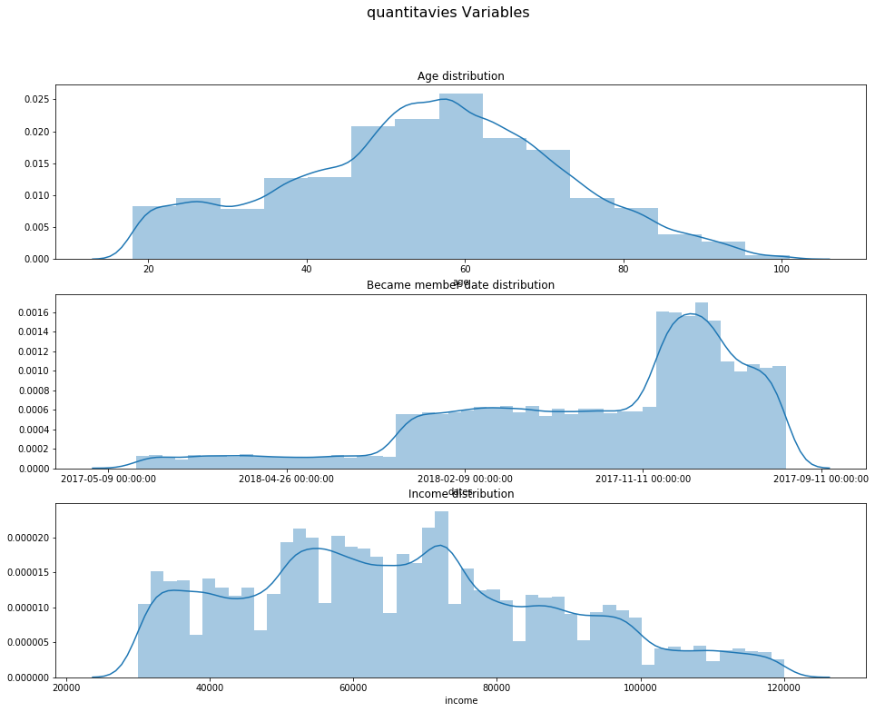

```python
fig,axes= plt.subplots(3,1,figsize=(16,12))
#fig.tight_layout()
fig.suptitle('quantitavies Variables', fontsize=16)


# Biuld an array with the ordinal dates to plot its distribution
ordinal_dates = np.array([d.toordinal() for d in df_master['became_member_on']])
# age distribution
axes[0].set_title('Age distribution', fontsize=12)
sns.distplot(df_master['age'], bins=15, ax=axes[0])

# Became member date
axes[1].set_title('Became member date distribution', fontsize=12)
axes[1].set(xlabel='dates', xticklabels=df_profile['became_member_on'])
sns.distplot(ordinal_dates, ax= axes[1])

# income distribution
axes[2].set_title('Income distribution', fontsize=12)
sns.distplot(df_master['income'], ax=axes[2]);
```

### *Qualitatives variables*

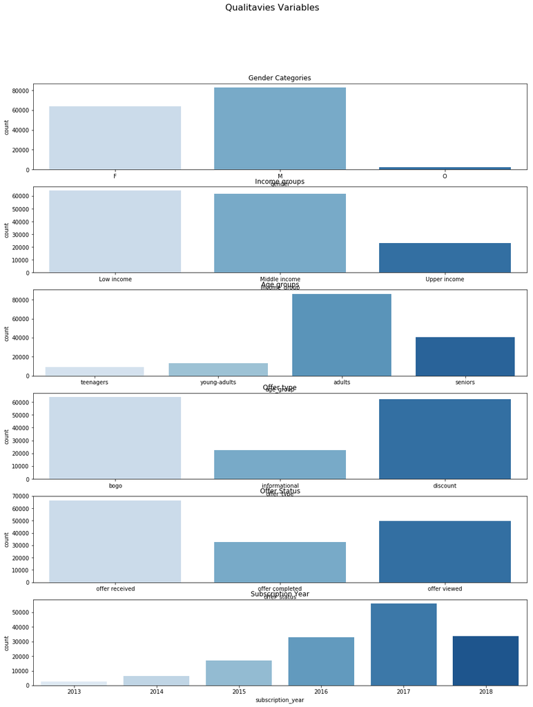

```python
fig,axes= plt.subplots(6,1,figsize=(16,20))
#fig.tight_layout()
fig.suptitle('Qualitavies Variables', fontsize=16)

# gender
axes[0].set_title('Gender Categories', fontsize=12)
sns.countplot(x='gender', palette='Blues', data=df_master, ax=axes[0])

# income group
axes[1].set_title('Income groups', fontsize=12)
sns.countplot(x='income_group', palette='Blues', data=df_master, ax=axes[1])

# age group
axes[2].set_title('Age groups', fontsize=12)
sns.countplot(x='age_group', palette='Blues', data=df_master, ax=axes[2])

# offer type
axes[3].set_title('Offer type', fontsize=12)
sns.countplot(x='offer_type', palette='Blues', data=df_master, ax=axes[3])

# offer status
axes[4].set_title('Offer Status', fontsize=12)
sns.countplot(x='offer_status', palette='Blues', data=df_master, ax=axes[4])

# subscription year
axes[5].set_title('Subscription Year', fontsize=12)
sns.countplot(x='subscription_year', palette='Blues', data=df_master, ax=axes[5]);
```

## 2.2 Bivariate Exploration

```python
def barchar(df, cat_var, order_list=None, rot=None, hue=None):

    plt.figure(figsize=(16,9))
    base_color = sns.color_palette()[0]
    sns.countplot(data= df, x=cat_var, hue=hue, color=base_color, order=order_list)

    #add annotations
    n_values = df.shape[0]
    cat_count = df[cat_var].value_counts()
    locs, labels = plt.xticks()
    plt.title(f'{cat_var}', fontsize=20)
    plt.xticks(rotation=rot);
```

**Subscription evolution by year and gender**

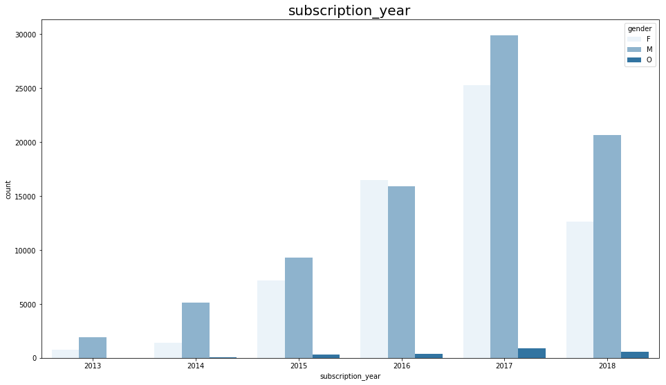

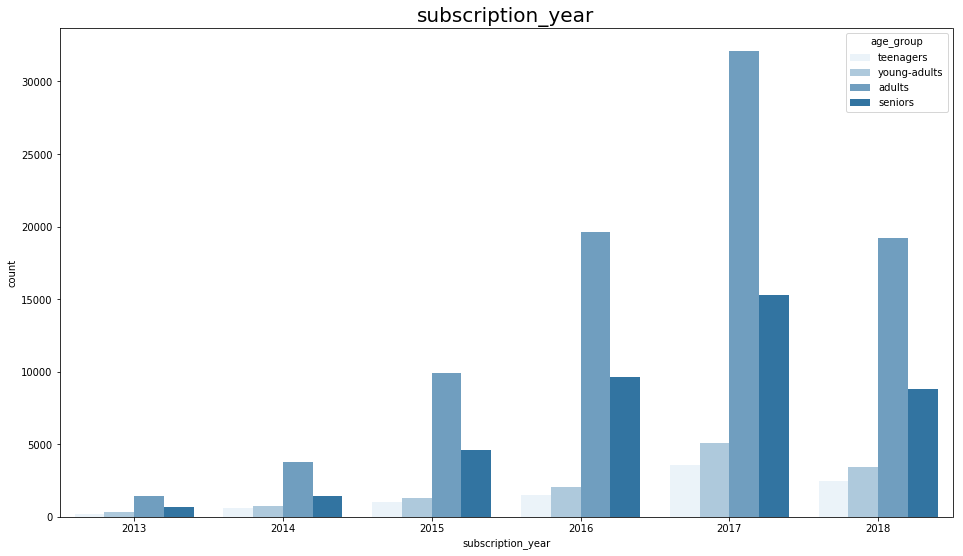

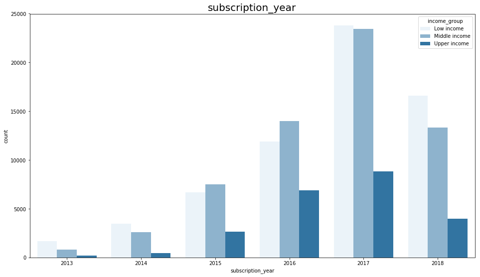

```python
barchar(df=df_master, cat_var='subscription_year', hue='gender')
barchar(df=df_master, cat_var='subscription_year', hue='age_group')
barchar(df=df_master, cat_var='subscription_year', hue='income_group')
```

> At this point we decided to see the evolution of subscribers based on 2 categories: gender and age group
> - Regarding gender, the proportion of M and F is paired from 2015, however during 2018, gender F significantly reduces its proportion
> - With regard to age groups, the market niche that this company seems to be targeting is definitely that of adults followed by seniors

**Income by gender and age**

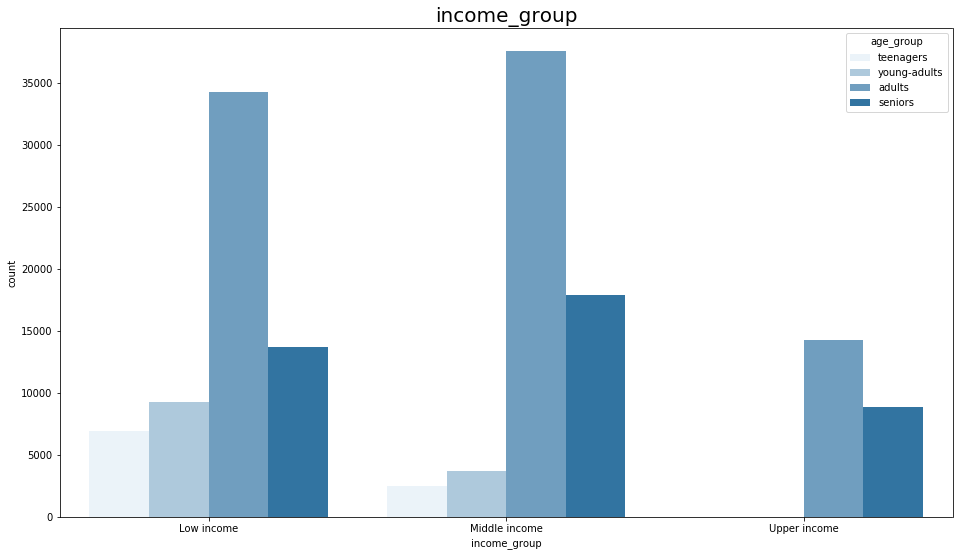

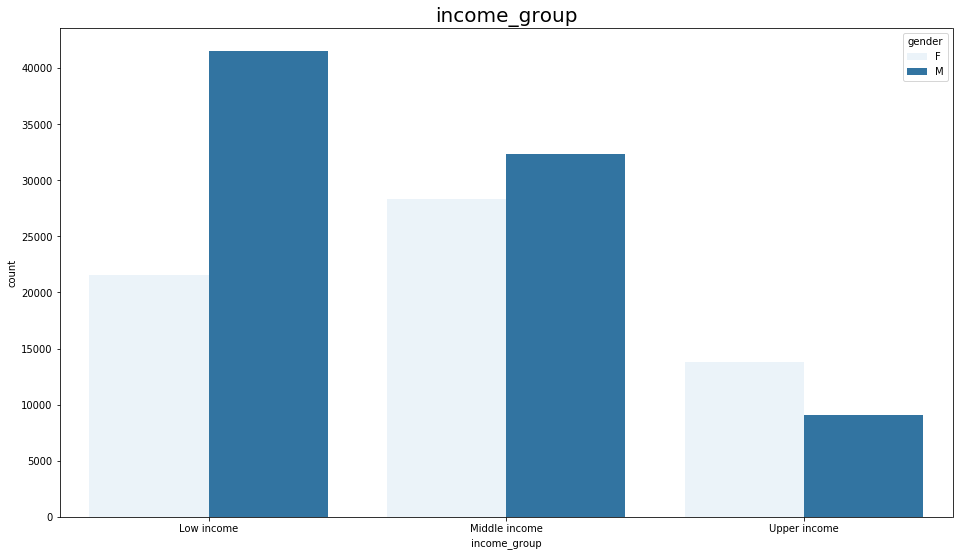

```python
barchar(df=df_master, cat_var='income_group', hue='age_group')
barchar(df=df_master.loc[df_master.gender != 'O'], cat_var='income_group', hue='gender')
```

> We continue with the analysis of demographic metrics. In this case we study the income with respect to age and gender:
> - For men, income is distributed in a decreasing way
> - Most women have a middle income. and it is worth noting that within the upper income they are the most represented gender
> - The only age groups that are distributed in each type of income are adults and seniors. They seem to be a good segment to focus a market analysis

**Offer status and Offer type**

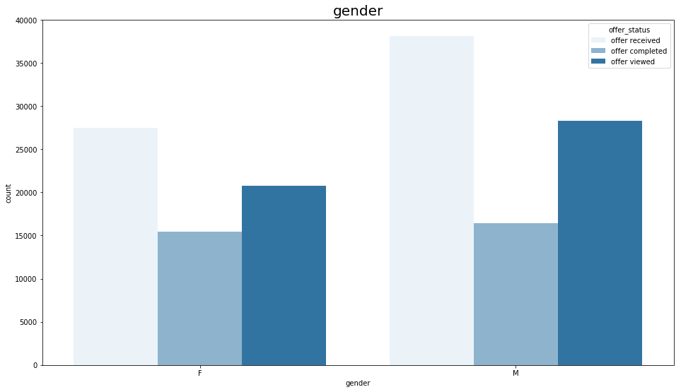

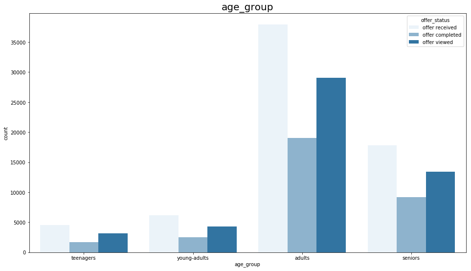

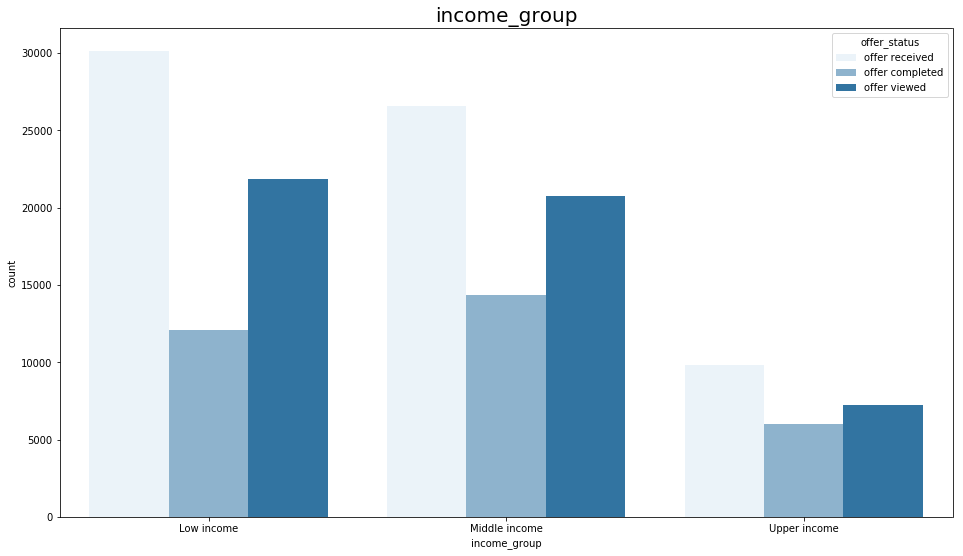

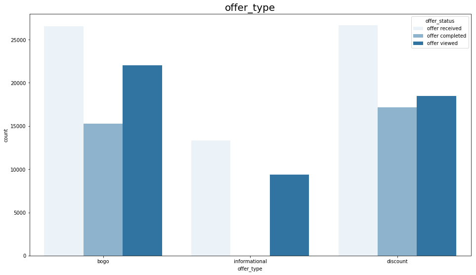

```python
barchar(df=df_master.loc[df_master.gender != 'O'], cat_var='gender', hue='offer_status')
barchar(df=df_master, cat_var='age_group', hue='offer_status')
barchar(df=df_master, cat_var='income_group', hue='offer_status')
barchar(df=df_master, cat_var='offer_type', hue='offer_status')
```

### Summary dataframe with demografics segmentation

> We decided to build an interactive dataframe using ipywidgets to have a better understanding of the behaviors that different consumer groups have. For this, we are first going to group the dataframe by the categorical fields that identify demographic groups:
> - gender
> - age
> - income

> and by the fields that describe the characteristics of the established offers:
> - offer type
> - offer status

```python
ALL = ['gender', 'age_group', 'income_group','offer_type', 'offer_status']

group_selector = widgets.SelectMultiple(
                        options=['gender', 'age_group', 'income_group','offer_type', 'offer_status'],
                        value=ALL,
                        #rows=10,
                        description='Categories',
                        disabled=False
)

output_grouped = widgets.Output()

def get_selected_group(change):
    global master_grouped
    output_grouped.clear_output()
    with output_grouped:
        if (change.new == ALL):
            master_grouped = df_master.groupby(by=ALL).count()['customer_id'].to_frame()
        else:
            master_grouped = df_master.groupby(by=change.new).count()['customer_id'].to_frame()
        display(master_grouped)

group_selector.observe(get_selected_group,names='value')
display(group_selector)
```

```python
display(output_grouped)
```

```python
master_grouped = df_master.groupby(by=ALL).count()['customer_id'].to_frame()
master_grouped
```

| gender | age_group | income_group | offer_type | offer_status | customer_id |
| --- | --- | --- | --- | --- | --- |
| F | teenagers | Low income | bogo | offer completed | 191.0 |
|  |  |  |  | offer received | 357.0 |
|  |  |  |  | offer viewed | 295.0 |
|  |  |  | discount | offer completed | 225.0 |
|  |  |  |  | offer received | 341.0 |
|  |  |  |  | offer viewed | 213.0 |
|  |  |  | informational | offer completed | NaN |
|  |  |  |  | offer received | 189.0 |
|  |  |  |  | offer viewed | 125.0 |
|  |  | Middle income | bogo | offer completed | 104.0 |
|  |  |  |  | offer received | 144.0 |
|  |  |  |  | offer viewed | 119.0 |
|  |  |  | discount | offer completed | 100.0 |
|  |  |  |  | offer received | 149.0 |
|  |  |  |  | offer viewed | 89.0 |
|  |  |  | informational | offer completed | NaN |
|  |  |  |  | offer received | 61.0 |
|  |  |  |  | offer viewed | 37.0 |
|  |  | Upper income | bogo | offer completed | NaN |
|  |  |  |  | offer received | NaN |
|  |  |  |  | offer viewed | NaN |
|  |  |  | discount | offer completed | NaN |
|  |  |  |  | offer received | NaN |
|  |  |  |  | offer viewed | NaN |
|  |  |  | informational | offer completed | NaN |
|  |  |  |  | offer received | NaN |
|  |  |  |  | offer viewed | NaN |
|  | young-adults | Low income | bogo | offer completed | 345.0 |
|  |  |  |  | offer received | 546.0 |
|  |  |  |  | offer viewed | 446.0 |
| ... | ... | ... | ... | ... | ... |
| O | adults | Upper income | informational | offer completed | NaN |
|  |  |  |  | offer received | 17.0 |
|  |  |  |  | offer viewed | 17.0 |
|  | seniors | Low income | bogo | offer completed | 37.0 |
|  |  |  |  | offer received | 59.0 |
|  |  |  |  | offer viewed | 47.0 |
|  |  |  | discount | offer completed | 27.0 |
|  |  |  |  | offer received | 53.0 |
|  |  |  |  | offer viewed | 37.0 |
|  |  |  | informational | offer completed | NaN |
|  |  |  |  | offer received | 35.0 |
|  |  |  |  | offer viewed | 25.0 |
|  |  | Middle income | bogo | offer completed | 31.0 |
|  |  |  |  | offer received | 38.0 |
|  |  |  |  | offer viewed | 37.0 |
|  |  |  | discount | offer completed | 33.0 |
|  |  |  |  | offer received | 38.0 |
|  |  |  |  | offer viewed | 37.0 |
|  |  |  | informational | offer completed | NaN |
|  |  |  |  | offer received | 15.0 |
|  |  |  |  | offer viewed | 14.0 |
|  |  | Upper income | bogo | offer completed | 6.0 |
|  |  |  |  | offer received | 7.0 |
|  |  |  |  | offer viewed | 7.0 |
|  |  |  | discount | offer completed | 3.0 |
|  |  |  |  | offer received | 3.0 |
|  |  |  |  | offer viewed | 3.0 |
|  |  |  | informational | offer completed | NaN |
|  |  |  |  | offer received | 3.0 |
|  |  |  |  | offer viewed | 3.0 |

324 rows × 1 columns

```python
STATUS = 'offer_status'

target_column = widgets.Dropdown(
    options=master_grouped.index.names,
    description='Target column',
    disabled=False,
)

output_pivoted = widgets.Output()

def get_pivoted_table(change):
    global master_pivoted
    output_pivoted.clear_output()
    with output_pivoted:
        if (change.new == STATUS):
            # build the index for the pivot table
            pivot_index = [field for field in master_grouped.index.names if field != STATUS]
            # create the pivote table with the desired values
            master_pivoted = pd.pivot_table(master_grouped, values='customer_id', index=pivot_index, columns=[STATUS])
        else:
            # build the index for the pivot table
            pivot_index = [field for field in master_grouped.index.names if field != change.new]
            # create the pivote table with the desired values
            master_pivoted = pd.pivot_table(master_grouped, values='customer_id', index=pivot_index, columns=[change.new])
        display(master_pivoted)

target_column.observe(get_pivoted_table,names='value')
display(target_column)
```

```python
display(output_pivoted)
```

```python
# build the index for the pivot table
pivot_index = [field for field in master_grouped.index.names if field != STATUS]
# create the pivote table with the desired values
master_pivoted = pd.pivot_table(master_grouped, values='customer_id', index=pivot_index, columns=[STATUS])
# Calculate the offer conversion rate
master_pivoted['offer conversion'] = round(master_pivoted['offer completed'] / master_pivoted['offer received'] *100,2)
master_pivoted
```

| gender | age_group | income_group | offer_status offer_type | offer completed | offer received | offer viewed | offer conversion |
| --- | --- | --- | --- | --- | --- | --- | --- |
| F | teenagers | Low income | bogo | 191.0 | 357.0 | 295.0 | 53.50 |
|  |  |  | discount | 225.0 | 341.0 | 213.0 | 65.98 |
|  |  |  | informational | NaN | 189.0 | 125.0 | NaN |
|  |  | Middle income | bogo | 104.0 | 144.0 | 119.0 | 72.22 |
|  |  |  | discount | 100.0 | 149.0 | 89.0 | 67.11 |
|  |  |  | informational | NaN | 61.0 | 37.0 | NaN |
|  | young-adults | Low income | bogo | 345.0 | 546.0 | 446.0 | 63.19 |
|  |  |  | discount | 334.0 | 511.0 | 319.0 | 65.36 |
|  |  |  | informational | NaN | 293.0 | 178.0 | NaN |
|  |  | Middle income | bogo | 147.0 | 222.0 | 178.0 | 66.22 |
|  |  |  | discount | 137.0 | 209.0 | 130.0 | 65.55 |
|  |  |  | informational | NaN | 103.0 | 70.0 | NaN |
|  | adults | Low income | bogo | 1238.0 | 2027.0 | 1724.0 | 61.08 |
|  |  |  | discount | 1373.0 | 2074.0 | 1433.0 | 66.20 |
|  |  |  | informational | NaN | 1018.0 | 757.0 | NaN |
|  |  | Middle income | bogo | 2009.0 | 2782.0 | 2366.0 | 72.21 |
|  |  |  | discount | 2195.0 | 2879.0 | 2191.0 | 76.24 |
|  |  |  | informational | NaN | 1427.0 | 1069.0 | NaN |
|  |  | Upper income | bogo | 1096.0 | 1412.0 | 1129.0 | 77.62 |
|  |  |  | discount | 1094.0 | 1379.0 | 966.0 | 79.33 |
|  |  |  | informational | NaN | 729.0 | 488.0 | NaN |
|  | seniors | Low income | bogo | 519.0 | 906.0 | 779.0 | 57.28 |
|  |  |  | discount | 590.0 | 878.0 | 614.0 | 67.20 |
|  |  |  | informational | NaN | 440.0 | 313.0 | NaN |
|  |  | Middle income | bogo | 1147.0 | 1593.0 | 1328.0 | 72.00 |
|  |  |  | discount | 1198.0 | 1588.0 | 1169.0 | 75.44 |
|  |  |  | informational | NaN | 807.0 | 589.0 | NaN |
|  |  | Upper income | bogo | 705.0 | 986.0 | 779.0 | 71.50 |
|  |  |  | discount | 730.0 | 935.0 | 609.0 | 78.07 |
|  |  |  | informational | NaN | 471.0 | 284.0 | NaN |
| ... | ... | ... | ... | ... | ... | ... | ... |
| O | teenagers | Low income | bogo | 5.0 | 11.0 | 9.0 | 45.45 |
|  |  |  | discount | 9.0 | 16.0 | 11.0 | 56.25 |
|  |  |  | informational | NaN | 5.0 | 4.0 | NaN |
|  |  | Middle income | bogo | 3.0 | 5.0 | 4.0 | 60.00 |
|  |  |  | discount | 1.0 | 5.0 | 2.0 | 20.00 |
|  |  |  | informational | NaN | 2.0 | 1.0 | NaN |
|  | young-adults | Low income | bogo | 8.0 | 23.0 | 21.0 | 34.78 |
|  |  |  | discount | 12.0 | 25.0 | 13.0 | 48.00 |
|  |  |  | informational | NaN | 15.0 | 11.0 | NaN |
|  |  | Middle income | bogo | 4.0 | 4.0 | 4.0 | 100.00 |
|  |  |  | discount | 5.0 | 6.0 | 4.0 | 83.33 |
|  |  |  | informational | NaN | 1.0 | NaN | NaN |
|  | adults | Low income | bogo | 53.0 | 75.0 | 62.0 | 70.67 |
|  |  |  | discount | 63.0 | 84.0 | 63.0 | 75.00 |
|  |  |  | informational | NaN | 44.0 | 33.0 | NaN |
|  |  | Middle income | bogo | 79.0 | 109.0 | 102.0 | 72.48 |
|  |  |  | discount | 84.0 | 111.0 | 102.0 | 75.68 |
|  |  |  | informational | NaN | 58.0 | 53.0 | NaN |
|  |  | Upper income | bogo | 19.0 | 23.0 | 22.0 | 82.61 |
|  |  |  | discount | 19.0 | 26.0 | 25.0 | 73.08 |
|  |  |  | informational | NaN | 17.0 | 17.0 | NaN |
|  | seniors | Low income | bogo | 37.0 | 59.0 | 47.0 | 62.71 |
|  |  |  | discount | 27.0 | 53.0 | 37.0 | 50.94 |
|  |  |  | informational | NaN | 35.0 | 25.0 | NaN |
|  |  | Middle income | bogo | 31.0 | 38.0 | 37.0 | 81.58 |
|  |  |  | discount | 33.0 | 38.0 | 37.0 | 86.84 |
|  |  |  | informational | NaN | 15.0 | 14.0 | NaN |
|  |  | Upper income | bogo | 6.0 | 7.0 | 7.0 | 85.71 |
|  |  |  | discount | 3.0 | 3.0 | 3.0 | 100.00 |
|  |  |  | informational | NaN | 3.0 | 3.0 | NaN |

90 rows × 4 columns

```python
GENDER_ALL = ['F', 'M', 'O']
AGE_GROUP_ALL = ['adults', 'seniors', 'teenagers', 'young-adults']
INCOME_GROUP_ALL = ['Low income', 'Middle income', 'Upper income']
OFFER_TYPE_ALL = ['bogo', 'discount', 'informational']


filtered_output = widgets.Output()

multisel_gender = widgets.SelectMultiple(
                        options=GENDER_ALL,
                        value=GENDER_ALL,
                        #rows=10,
                        description='Gender',
                        disabled=False)

multisel_age_group = widgets.SelectMultiple(
                        options=AGE_GROUP_ALL,
                        value=AGE_GROUP_ALL,
                        description='Age group',
                        disabled=False)

multisel_income_group = widgets.SelectMultiple(
                        options=INCOME_GROUP_ALL,
                        value=INCOME_GROUP_ALL,
                        description='Income',
                        disabled=False)

multisel_offer_type = widgets.SelectMultiple(
                        options=OFFER_TYPE_ALL,
                        value=OFFER_TYPE_ALL,
                        description='Offer type',
                        disabled=False)

def common_filtering(gender, age_group=None, income_group=None, offer_type=None):
    global master_filtred
    filtered_output.clear_output()
    if (gender == GENDER_ALL) & (age_group == AGE_GROUP_ALL) & (income_group == INCOME_GROUP_ALL) & (offer_type ==OFFER_TYPE_ALL):
        master_filtered = master_pivoted

    elif (gender == GENDER_ALL):
        master_filtered = master_pivoted.loc[(master_pivoted.index.get_level_values('gender').isin(gender))]

    elif (gender == GENDER_ALL) & (age_group == AGE_GROUP_ALL):
        master_filtered = master_pivoted.loc[(master_pivoted.index.get_level_values('gender').isin(gender)) &
                                       (master_pivoted.index.get_level_values('age_group').isin(age_group))]

    elif (gender == GENDER_ALL) & (age_group == AGE_GROUP_ALL) & (income_group == INCOME_GROUP_ALL):
        master_filtered = master_pivoted.loc[(master_pivoted.index.get_level_values('gender').isin(gender)) &
                                       (master_pivoted.index.get_level_values('age_group').isin(age_group)) &
                                       (master_pivoted.index.get_level_values('income_group').isin(income_group))]

    else:
        master_filtered = master_pivoted.loc[(master_pivoted.index.get_level_values('gender').isin(gender)) &
                                       (master_pivoted.index.get_level_values('age_group').isin(age_group)) &
                                       (master_pivoted.index.get_level_values('income_group').isin(income_group)) &
                                       (master_pivoted.index.get_level_values('offer_type').isin(offer_type))]
    with filtered_output:
        display(master_filtered)

def filter_multisel_gender(change):
    common_filtering(change.new, multisel_age_group.value, multisel_income_group.value, multisel_offer_type.value)

def filter_multisel_age_group(change):
    common_filtering(multisel_gender.value, change.new, multisel_income_group.value, multisel_offer_type.value)

def filter_multisel_income_group(change):
    common_filtering(multisel_gender.value, multisel_age_group.value, change.new, multisel_offer_type.value)

def filter_multisel_offer_type(change):
    common_filtering(multisel_gender.value, multisel_age_group.value, multisel_income_group.value, change.new)

multisel_gender.observe(filter_multisel_gender, names='value')
multisel_age_group.observe(filter_multisel_age_group, names='value')
multisel_income_group.observe(filter_multisel_income_group, names='value')
multisel_offer_type.observe(filter_multisel_offer_type, names='value')


display(multisel_gender)
display(multisel_age_group)
display(multisel_income_group)
display(multisel_offer_type)
```

```python
display(filtered_output)
```

## 3 Data Modeling

> Now that we have built a table that describes, based on the different categorical fields, how the different demographic segmentations respond to each one of the types of offers present in the exercise, we can build a Machine learning model that indicates how a certain demographic profile would respond to the different types of offers

> To validate the impact that Starbucks promotions have, we are going to exclude received offers from the study, in this way we will only take into account the offers seen over the completed ones.

```python
df_master = df_master.loc[df_master['offer_status'] != 'offer received']
```

```python
# Build dictionary mappings for Categorical fields
status_map = {'offer completed':1, 'offer viewed':2}
type_map = {'bogo':1, 'informational':2, 'discount':3}
gender_map = {'F':1, 'M':2, 'O':3}
offers_id = df_master['offer_id'].unique().tolist()
offer_id_map = {value:index for index, value in enumerate(offers_id, start=1)}

# map Offer status with numeric values
df_master['offer_status'] = df_master['offer_status'].map(status_map)
# map Offer type with numeric values
df_master['offer_type'] = df_master['offer_type'].map(type_map)
# map gender with numeric values
df_master['gender'] = df_master['gender'].map(gender_map)
# map offer_id with numeric values
df_master['offer_id'] = df_master['offer_id'].map(offer_id_map)

# Rename 'reward_x' column to 'reward'
df_master.rename(columns ={'reward_x':'reward'}, inplace = True)
```

```python
X = df_master[['gender', 'age', 'income', 'subscription_year', 'offer_id', 'time', 'amount', 'reward', 'difficulty', 'duration', 'email', 'mobile', 'social', 'web', 'offer_type']]
Y = df_master[['offer_status']]
```

```python
X.head()
```

|  | gender | age | income | subscription_year | offer_id | time | amount | reward | difficulty | duration | email | mobile | social | web | offer_type |
| --- | --- | --- | --- | --- | --- | --- | --- | --- | --- | --- | --- | --- | --- | --- | --- |
| 1 | 1 | 55.0 | 112000.0 | 2017 | 1 | 22 | 0.0 | 5.0 | 5 | 7 | 1 | 1 | 0 | 1 | 1 |
| 3 | 1 | 75.0 | 100000.0 | 2017 | 1 | 0 | 0.0 | 0.0 | 5 | 7 | 1 | 1 | 0 | 1 | 1 |
| 4 | 1 | 75.0 | 100000.0 | 2017 | 1 | 5 | 0.0 | 5.0 | 5 | 7 | 1 | 1 | 0 | 1 | 1 |
| 6 | 2 | 68.0 | 70000.0 | 2018 | 1 | 17 | 0.0 | 0.0 | 5 | 7 | 1 | 1 | 0 | 1 | 1 |
| 7 | 2 | 68.0 | 70000.0 | 2018 | 1 | 21 | 0.0 | 5.0 | 5 | 7 | 1 | 1 | 0 | 1 | 1 |

```python
Y.head()
```

|  | offer_status |
| --- | --- |
| 1 | 1 |
| 3 | 2 |
| 4 | 1 |
| 6 | 2 |
| 7 | 1 |

```python
# Feature normalization
scaler = MinMaxScaler()
features = ['age', 'income', 'subscription_year', 'time', 'amount', 'reward', 'difficulty', 'duration']
X_scaled = X.copy()
X_scaled[features] = scaler.fit_transform(X_scaled[features])
X_scaled.head()
```

|  | gender | age | income | subscription_year | offer_id | time | amount | reward | difficulty | duration | email | mobile | social | web | offer_type |
| --- | --- | --- | --- | --- | --- | --- | --- | --- | --- | --- | --- | --- | --- | --- | --- |
| 1 | 1 | 0.445783 | 0.911111 | 0.8 | 1 | 0.758621 | 0.0 | 0.5 | 0.25 | 0.571429 | 1 | 1 | 0 | 1 | 1 |
| 3 | 1 | 0.686747 | 0.777778 | 0.8 | 1 | 0.000000 | 0.0 | 0.0 | 0.25 | 0.571429 | 1 | 1 | 0 | 1 | 1 |
| 4 | 1 | 0.686747 | 0.777778 | 0.8 | 1 | 0.172414 | 0.0 | 0.5 | 0.25 | 0.571429 | 1 | 1 | 0 | 1 | 1 |
| 6 | 2 | 0.602410 | 0.444444 | 1.0 | 1 | 0.586207 | 0.0 | 0.0 | 0.25 | 0.571429 | 1 | 1 | 0 | 1 | 1 |
| 7 | 2 | 0.602410 | 0.444444 | 1.0 | 1 | 0.724138 | 0.0 | 0.5 | 0.25 | 0.571429 | 1 | 1 | 0 | 1 | 1 |

```python
# creating training and testing sets
X_train, X_test, y_train, y_test = train_test_split(X, Y, test_size=0.3, random_state=42)
```

```python
def model_train_and_predict(model, X_train=X_train, y_train=y_train):
    # fit the model
    model.fit(X_train, y_train)
    # predict the vañues
    y_pred = model.predict(X_test)

    return y_pred

def model_evaluate(y_true, y_pred):
    #calculate accuracy
    accuracy = accuracy_score(y_true, y_pred)
    print('Accuracy: %.3f' % accuracy)
    # calculate prediction
    precision = precision_score(y_true, y_pred)
    print('Precision: %.3f' % precision)
    # calculate recall
    recall = recall_score(y_true, y_pred)
    print('Recall: %.3f' % recall)
    # calculate score
    score = f1_score(y_true, y_pred)
    print('F-Measure: %.3f' % score)
```

### Decision Tree

```python
# set the model
model = DecisionTreeClassifier()
# train the model and get predictions
y_pred = model_train_and_predict(model)
# evaluate predictions
model_evaluate(y_test, y_pred)
```

```
Accuracy: 1.000
Precision: 1.000
Recall: 1.000
F-Measure: 1.000
```

### Random Forest

```python
# set the model
model = RandomForestRegressor(n_estimators = 100, random_state = 42)
# train the model and get predictions
y_pred = model_train_and_predict(model)
# evaluate predictions
model_evaluate(y_test, y_pred)
```

```
Accuracy: 1.000
Precision: 1.000
Recall: 1.000
F-Measure: 1.000
```

### Logistic Regression

```python
# set the model
model = LogisticRegression()
# train the model and get predictions
y_pred = model_train_and_predict(model)
# evaluate predictions
model_evaluate(y_test, y_pred)
```

```
Accuracy: 1.000
Precision: 1.000
Recall: 1.000
F-Measure: 1.000
```

### Support Vector Machine

```python
# set the model
model = SVC(gamma = 'auto')
# train the model and get predictions
y_pred = model_train_and_predict(model)
# evaluate predictions
model_evaluate(y_test, y_pred)
```

```
Accuracy: 0.867
Precision: 0.916
Recall: 0.729
F-Measure: 0.812
```

### Naive Bayes

```python
# set the model
model = GaussianNB()
# train the model and get predictions
y_pred = model_train_and_predict(model)
# evaluate predictions
model_evaluate(y_test, y_pred)
```

```
Accuracy: 1.000
Precision: 1.000
Recall: 1.000
F-Measure: 1.000
```

### K-Nearest Neighbors

```python
# set the model
model = KNeighborsClassifier()
# train the model and get predictions
y_pred = model_train_and_predict(model)
# evaluate predictions
model_evaluate(y_test, y_pred)
```

```
Accuracy: 0.838
Precision: 0.831
Recall: 0.737
F-Measure: 0.781
```

## Conclusions

### Hyperparameter tunning

> The results obtained leave us satisfied in terms of the high accurecy in most of the models executed. In this way, we discard the incorporation of parameter tunning. However, in the future, we consider it interesting to implement a previous PCA to focus the study on the most significant features.

> On the other hand, using the Xgboost model may be a good possibility also due to its robust predictions and its easy implementation aswell.

### Workflow recap

> en ina primer instancia nos concentramos en estructurar los datas sets comprender la informacion que no proveen y hacer el pertinente data wrangling necesario para continuar con el EDA. Estas transformaciones intermedia sumadas al analisis y sus respectivas visualizaciones nos brindaron una perspectiva mas aguda de las caracteristicas de los datasets y sus posibilidades. Amodo de resumen decidimos implementar una tabla interactiva que describiera el ratio de convertibilidad entre los distintos tipos de oferta para cada uno de lo segmentos demograficos. Este analisis descriptivos nos dio una imagen muy completa respecto a la diversidad de resultados encontrados. Finalmente, convinamos los datasets en una tabla master la cual empleamos para construir los modelos de machine learning

### Reflection

> The fact of being able to be working and analyzing business data in a study environment is highly valuable and makes the final project very attractive. Here the skills developed throughout the course should be applied as a means to provide a solution to a specific client. It was a very complete training for me and I had a lot of fun reflecting on the insights that could be extracted from this data